# Evaluating Variations in Countermovement Jump Performance among Rugby Players

## Brief overview on Functional Data analysis

A functional curve denoted by $x(t)$ can be expressed by the equation:

$y_{j}= x(t_{j}) + e_{j}$

where $y_j$ is the raw data (typically measured with noise), $x(t_{j})$ is the smooth signal, $e_{j}$ is the noise and with $t$ in a continuum (usually time). We employ a technique known as basis function expansion to perform smoothing and noise removal and estimate the function $x(t)$. This approach involves representing $x(t)$ as a linear combination of basis functions, denoted by $\theta_{k}(t)$.

$x(t)= \sum_{k=1}^{K} \vartheta_{k}\theta_{k}(t)$.

The objective is to find the basis coefficients, $\vartheta_{k}$ that weight each basis function appropriately to reconstruct the underlying function $x(t)$ from the given data. These coefficients are crucial as they dictate the contributions of each basis function to the overall representation of $x(t)$. By adjusting the $\vartheta_{k}$ values, the basis functions can be scaled, shifted, or combined to fit the observed data points best and smooth out any noise or irregularities in the data. A crucial consideration is selecting the appropriate expansion order, denoted as $T$. A larger value of $T$ generally leads to a better fit to the data, allowing for greater flexibility in capturing complex patterns. However, a trade-off exists, as a larger $T$ also increases the risk of over-fitting. On the other hand, if $T$ is chosen to be too small, the model might fail to capture important aspects of the smooth function $T$ that we are trying to estimate. In this case, we tend to consider smaller values of $T$ for the expansion to reduce variance in the model. Hence, to address this trade-off, we employ the Penalised Residual Sum of Squares (PENSSE); a Smoothing with a roughness penalty approach for finding the appropriate balance for the value of $T$ essential in obtaining a reliable and accurate estimation of the smooth function. Mathematically we can express the PENSSE as:

$PENSSE =\sum_{j=1}^{n} [ y_j - x(t_j) ]^2 + \lambda \int_{T} [ D^2x(t) ]^2 dt$ $= \sum_{j=1}^{n} [ y_j - \sum_{k=1}^{T} \vartheta_k \theta_k(t_j) ]^2 +\lambda \int_{T} [ D^2x(t) ]^2 dt$ $= |y - \theta \vartheta|^2 + \lambda | D^2x(t) |^2$ $= |y - \theta \vartheta|^2 + \lambda PEN_2(x)$

hence $\hat{\vartheta}$ the estimated coefficient vector will be

$\hat{\vartheta}=(\theta^{'} \theta + \lambda R)^{-1} \theta^{'} y$.

$|y - \theta \vartheta|^2$ is the fit to the data measured as the residual sum of squares, $PEN_2(x)$ is the variability of the function $X(t)$ that measures its roughness, and $\lambda$ serves as a smoothing parameter, determining the balance between fitting the data and controlling the variability of the function $x(t)$. The value of $\lambda$ influences the extent to which the estimation adjusts to the data points, and a higher $\lambda$ will prioritise smoother functions, while a lower $\lambda$ may result in a fit that closely matches the data points even if it leads to more variability in the estimation. The choice of $\lambda$ is crucial in finding the right balance between fitting the data and obtaining a function that generalises well to new observations.

A popular measure for choosing the optimum $\lambda$ is through the generalised cross-validation measure (GCV) given as:

$GCV(\lambda)=(\frac{n}{n-df(\lambda)})(\frac{SSE}{n-df(\lambda)})$,

where

$df(\lambda) = tr[\underline{H}]=tr[\underline{\theta}(\underline{\theta}^{'}\underline{\theta} + \lambda\underline{R})^{-1}\underline{\theta}^{'}]$

is the trace of the smoothing matrix.

To determine the optimal value of the smoothing parameter $\lambda$ that minimises the GCV criterion, a model is fitted for a range of $\lambda$ values specified on a logarithmic scale and for each fitted model, the corresponding GCV value is calculated. The goal is to find the $\lambda$ value that yields the smallest GCV value, indicating the best trade-off between fitting the data and controlling the model’s complexity.

To accomplish this, the GCV values are plotted against the corresponding values of $\lambda$. The optimal $\lambda$ is then identified as the point on the plot where the GCV reaches its minimum.

#Force Curve of the 34 Subjects without Alignment

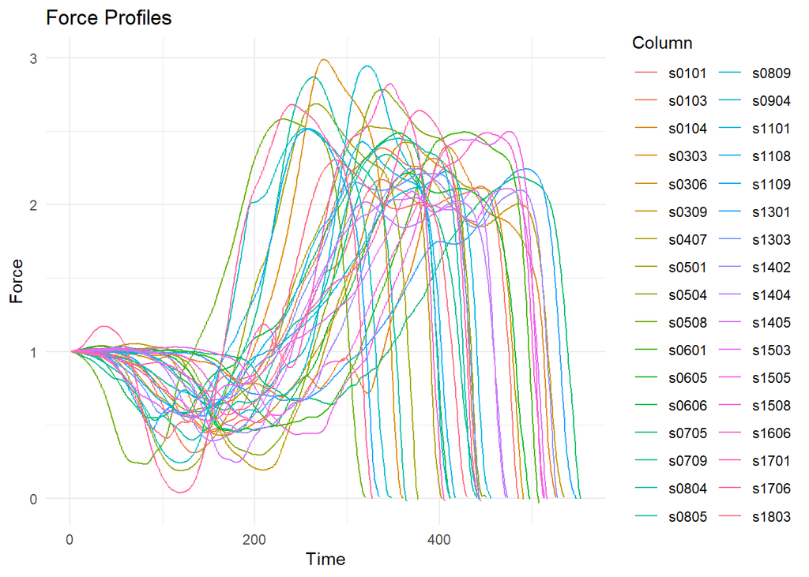

The plot displays the force profiles of 34 subjects, revealing their jump patterns. Notably, there are noticeable variations in the later phases of the jumps. To facilitate a meaningful comparison of the curves and mitigate the influence of these end-phase variations, we employ linear time normalization, effectively standardizing the time range to (0, 1) before smoothing.

## Choosing lambda the optimal smoothing parameter

Firstly we extract and analyse the force profile of one subject in order to obtain the optimal smoothing parameter $\lambda$.

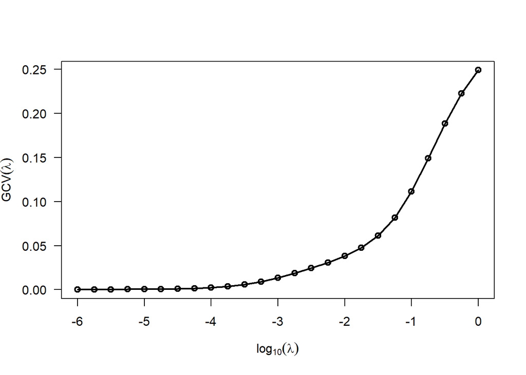

# Smoothing using B-splines

```r
# Initialize a list to store the coefficients
coeff_list <- list()

# Initialize a list to store the smoothed functional data objects
force.fd <- list()

# Loop through columns of Raw_Force
for (i in 1:ncol(Raw_Force)) {

  # Remove missing values from the current column
  s1 <- na.omit(Raw_Force[, i])

  # Extract and normalize the time values
  time <- as.numeric(time(s1))
  Min <- min(time)
  Max <- max(time)

  # Linear time normalization function
  time_norm <- function(x) {
    norm_x <- matrix()
    for (i in 1:length(x)) {
      norm_x <- (x - Min) / (Max - Min)
      return(norm_x)
    }
  }

  # Combine time and variable into a matrix
  DF <- cbind(time, s1)

  # Apply linear time normalization to the time column
  DF[, 1] <- time_norm(DF[, 1])

  # Define the time range for the basis
  TimeRng <- c(0, 1)

  # Set up the B-spline basis
  force_basis <- create.bspline.basis(c(0, 1), norder = 4, nbasis = 300)

  # Set up the penalty object penalizing the 2nd derivative and initially set lambda = 0.0001
  force_fdPar = fdPar(fdobj = force_basis, Lfdobj = 2, lambda = 0.0001)

  # Smooth the data using the penalty object
  force.pen.smooth = smooth.basis(argvals = DF[, 1], y = DF[, 2], fdParobj = force_fdPar)

  # Create a new data frame for the coefficients and assign the values
  coeff_df <- data.frame(t(force.pen.smooth$fd[["coefs"]]))

  # Store the smoothed functional data object in the force.fd list
  force.fd[[i]] <- force.pen.smooth$fd

  # Add the data frame to the coeff_list
  coeff_list[[i]] <- coeff_df

  # Plot the smooth curve(Remove "#' below to see the plots)
  #plot(DF[, 1], DF[, 2], type = 'p', lwd = 0.00005, xlab = 'Time', ylab = 'Force',
       #main = paste0(colnames(Raw_Force[i])))
  #lines(force.pen.smooth$fd, col = 'red')

}
```

#creating the force fd-object class to be used for further analysis

# Force Curves after Alignment and smoothing

```r
# Create a functional data object (FD) using the coefficients, basis, and fdnames
Force_fd <- fd(coefs, force_basis, fdnames = fdname)

# Check the class of the resulting FD
class(Force_fd)
```

```
## [1] "fd"
```

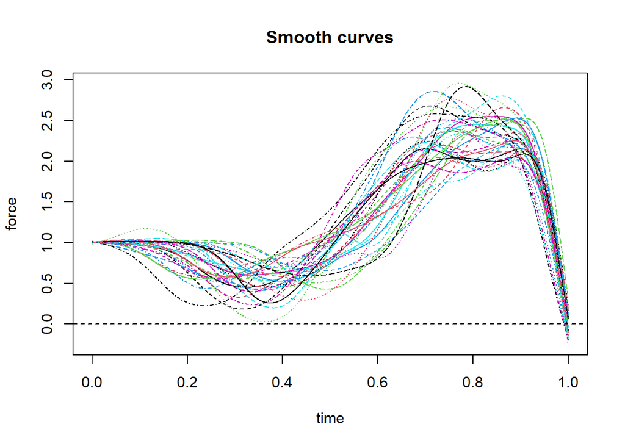

```
## [1] "done"
```

```r
# Plot the smooth curves using the created FD
plot(Force_fd, xlab = 'time', ylab = 'force', main = 'Smooth curves')
```

By aligning and smoothing the force curves, we effectively eliminate noise, eliminate the phase variation at the end of the curve and enhance the clarity of the data.

## Functional PCA

We employ FPCA as a means of dimension reduction and as well examine the different jump variations among the force data

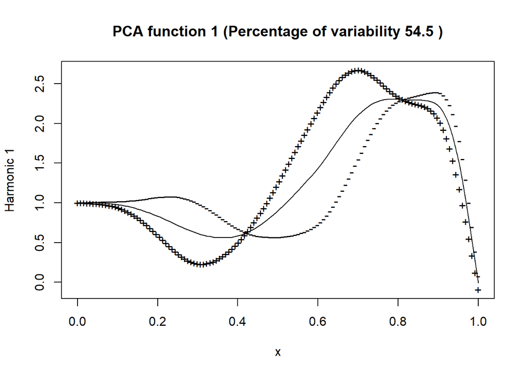

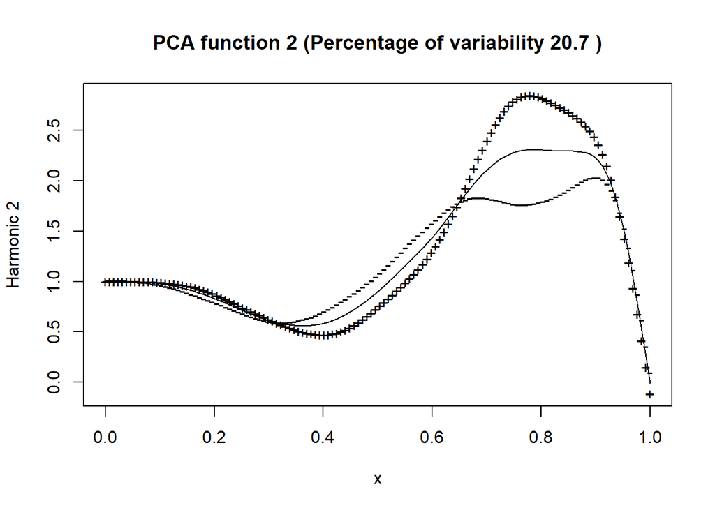

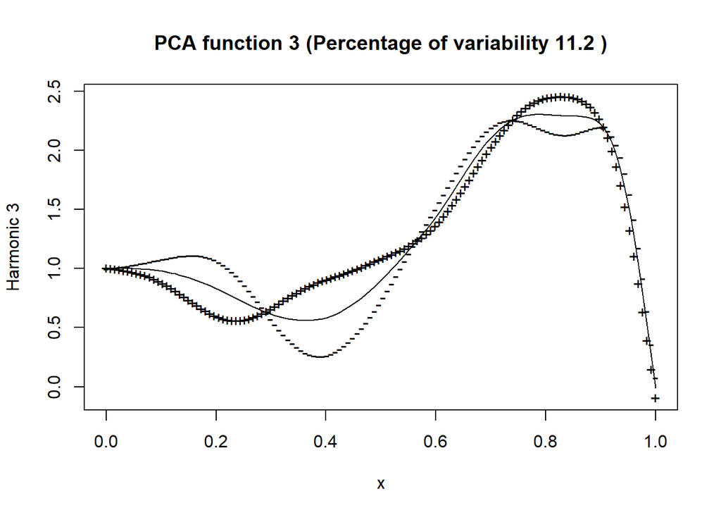

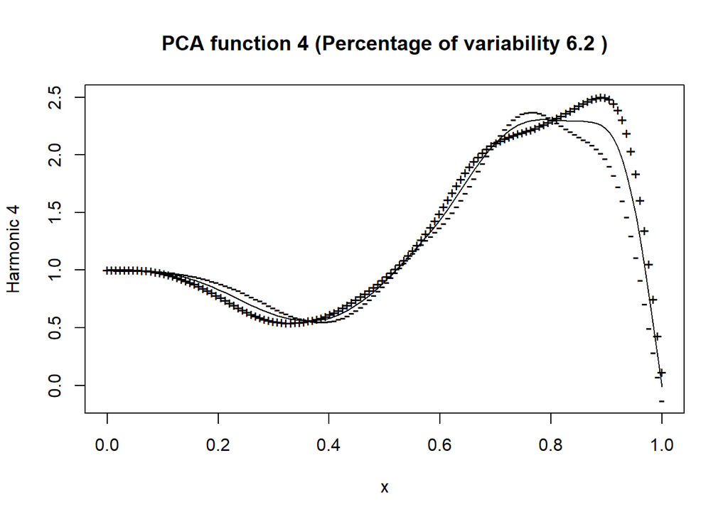

```r
force.pcalist = pca.fd(Force_fd,4,harmfdPar=fdPar(Force_fd))
plot(force.pcalist)
```

#Cumulative proportion of variability explained by the Pcs

| X1.4 | cum.propvar |
| --- | --- |
| 1 | 0.5453238 |
| 2 | 0.7519810 |
| 3 | 0.8642918 |
| 4 | 0.9265719 |

Result interpretation:

The functional principal components were calculated for the resulting smoothed force curves, and four functional principal components were utilised as they accounted for 93% of the total variability. The first, second, third, and fourth functional principal components accounted for $54.5, 20.7, 11.2,\& 6.2$ percent of the total variability, respectively. The above plots display the average curve and two additional curves obtained by adding (indicated by a plus sign) and subtracting (indicated by a minus sign) a multiple of the functional principal component from the mean curve.

The jump variations from the FPCA indicated subjects with two distinct characteristics or features; early and late peak force.

## Functional Clustering

To determince subgroups Subjects based on their Jump pattern we employ functional clustering methods and standard K-means clustering on the FPC scores

#FDA K-means

## Functional Clustering

#FDA K-means In this FDA clustering algorithm, we facilitate the grouping of curves based on their phase and amplitude characteristics. The method employs various warping classes to register the curves along the time domain. However, it’s noteworthy that in this specific project, we’ve opted for a no warping class approach. This decision was made due to the prior alignment of the initial curves, resulting in enhanced clarity and interpretability, particularly towards the end of the force curve.

#Comparing different clustering solutions using FDA-kmeans

```r
caps<-compare_caps(x=T_R,y=Force_fd,n_clusters=1:6, clustering_method="kmeans", warping_class ="none",centroid_type = "mean",cluster_on_phase = FALSE)
```

#Plotting the within sum of squares for selecting the no of clusters

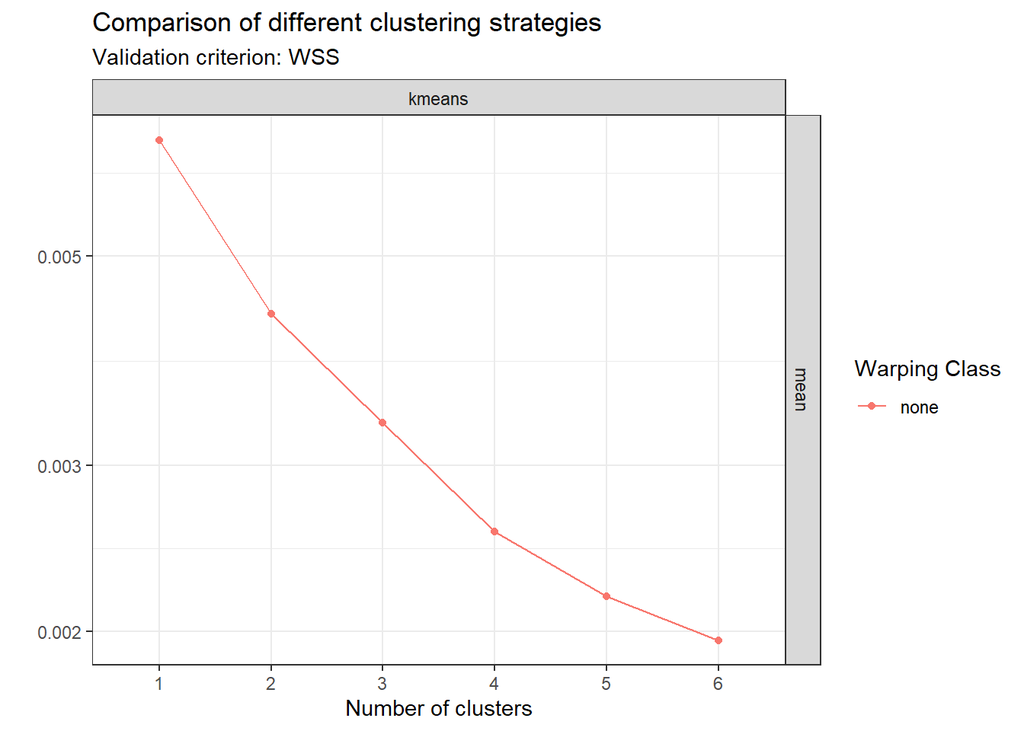

The selection of K=2 is based on a subjective choice, primarily influenced by the observation of the first noticeable elbow point in the within-group sum of squares (WSS) curve.Using two cluster solutions we can visualize the two groups below,

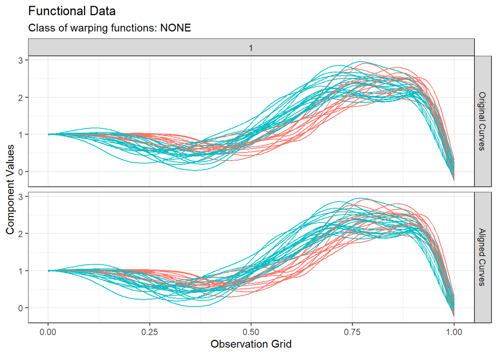

```r
# Perform Functional Data Analysis K-Means clustering
# - 'x' represents the data for time normalization
# - 'y' represents the smoothed force curves
# - 'n_clusters' specifies the number of clusters (2 in this case)
# - 'warping_class' defines the warping class (in this case, "none" for no warping)
# - 'cluster_on_phase' determines whether clustering is based on phase (set to FALSE)
# - 'use_verbose' controls verbose output (set to FALSE for no verbosity)
N.Kmeans.amp_cluster2 <- fdakmeans(
  x = T_R,
  y = Force_fd,
  n_clusters = 2,
  warping_class = "none",
  cluster_on_phase = FALSE,
  use_verbose = FALSE
)

# Plot the amplitude-based clusters obtained from FDA K-Means
plot(N.Kmeans.amp_cluster2, type = 'amplitude')
```

## Standard K-Means Clustering on FPC scores

In this second clustering strategy we extract the FPC scores and apply the standard K-means #pc scores

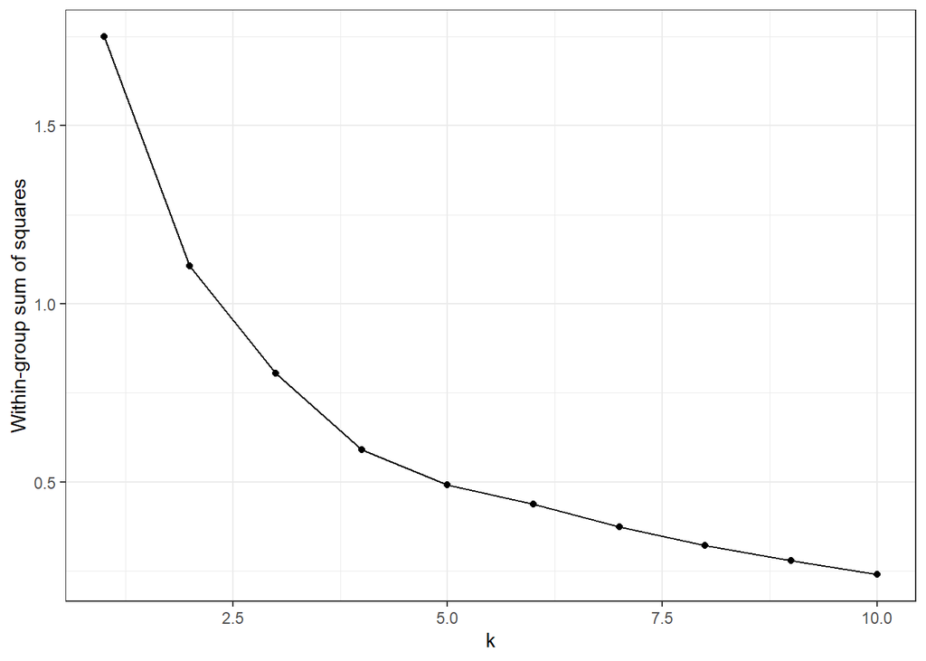

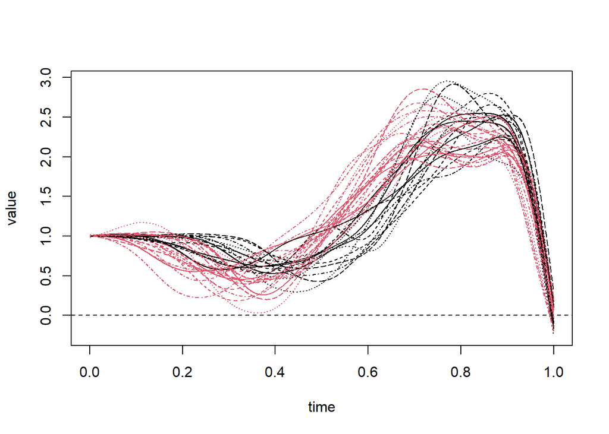

```
## [1] "done"
```

```r
# Set a random seed for reproducibility
set.seed(4)

# Perform k-means clustering with 2 centers on the 'FPC scores'
K_cl2 <- kmeans(scores, centers = 2, nstart = 20)

# Plot the smoothed force curves (Force_fd) with colors based on the cluster assignments
plot(Force_fd, col = K_cl2$cluster)
```

## Estimating the consistency of the cluster solutions from the two methods

We utilize the Rand Index (RI) as an essential metric to evaluate the similarity between two data partitions. This evaluation helps us assess the effectiveness of both the FDA K-means and K-means(on FPC scores) clustering strategies.

## class Agreement between the functional Kmeans and kmeans algorithm clusters

```
## $diag
## [1] 0.9705882
##
## $kappa
## [1] 0.9386282
##
## $rand
## [1] 0.9411765
##
## $crand
## [1] 0.8823473
```

The high scores indicate that the clustering results from the FDA K-means and K-means on FPC scores are in high agreement and they produce relatively compact, well-separated clusters

# Are there significant difference between the groups observed?

We employ the Functional T.test to further investigate if they are significant differences among the clusters observed.

# Group 1

```r
# Extract columns from the 'coefs' matrix where cluster membership is 1
group_1 <- coefs[, which(N.Kmeans.amp_cluster2$memberships == 1)]

# Define the time vector
time <- 1:300

# Get the column names (reps) of the 'group_1' matrix
reps <- colnames(group_1)

# Create a list for specifying the functional data object names (fdnames)
fdname <- list('time' = time, 'reps' = reps, 'values' = 'value')

# Create the functional data object for 'group_1'
group1.fd <- fd(group_1, force_basis, fdnames = fdname)
```

# Group 2

```r
# Extract columns from the 'coefs' matrix where cluster membership is 2
group_2 <- coefs[, which(N.Kmeans.amp_cluster2$memberships == 2)]

# Define the time vector
time <- 1:300

# Get the column names (reps) of the 'group_2' matrix
reps <- colnames(group_2)

# Create a list for specifying the functional data object names (fdnames)
fdname <- list('time' = time, 'reps' = reps, 'values' = 'value')

# Create the functional data object for 'group_2' and store it as 'group2.fd'
group2.fd <- fd(group_2, force_basis, fdnames = fdname)
```

# Visualizing the mean curves of both groups

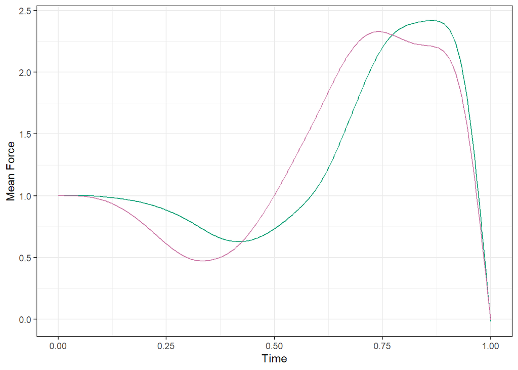

```r
# Create a data frame 'Force.mean.dat' with columns 'x', 'mean.group1', and 'mean.group2'
Force.mean.dat <- data.frame(
  x = seq(0, 1, length = 300),
  mean.group1 = eval.fd(seq(0, 1, length = 300), mean.fd(group1.fd)),
  mean.group2 = eval.fd(seq(0, 1, length = 300), mean.fd(group2.fd))
)

# Rename the columns of 'Force.mean.dat'
names(Force.mean.dat) <- c("x", "group_1", "group_2")

# Create a ggplot to visualize the mean force curves for both groups
ggplot(data = Force.mean.dat, aes(x = x, y = group_1)) +
  geom_line(colour = "#009E73") +  # Line for 'group_1' with green color
  geom_line(aes(x = x, y = group_2), colour = "#CC79A7") +  # Line for 'group_2' with pink color
  xlab("Time") +
  ylab("Mean Force") +
  theme_bw()
```

## Functional t.test

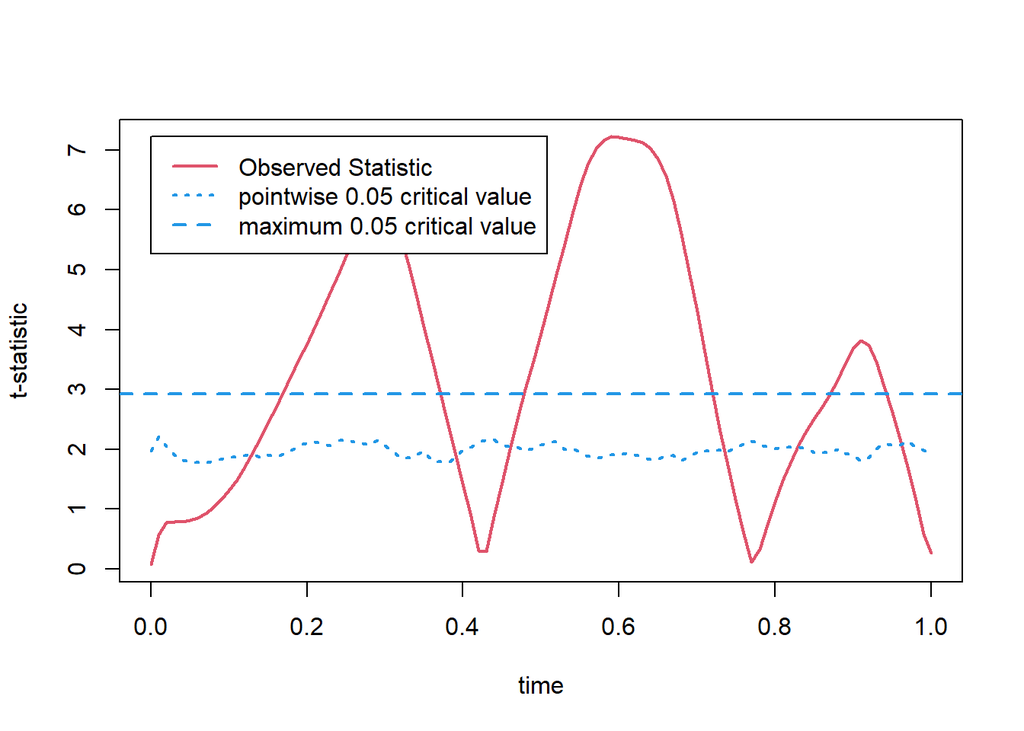

# Conclusion:

In conclusion, employing FDA methods has proven instrumental in discerning and categorizing rugby players into two homogeneous groups based on their jump patterns, specifically analyzing the force curve. The nuanced insights derived from these jump patterns, distinguished by their unique time to peak force, offer invaluable information for performance coaches.

Understanding the temporal dynamics of force exertion during jumps enables coaches to tailor training strategies with precision. By recognizing and capitalizing on the distinct characteristics within each group, performance coaches can design targeted and effective training regimens that address the specific needs and potential areas of improvement for each subgroup of players.

Ultimately, the application of FDA not only enhances our understanding of the intricacies of jump patterns among rugby players but also empowers coaches to optimize training programs, fostering individualized and performance-driven approaches. This analytical approach marks a significant stride in elevating the efficacy of training strategies, ultimately contributing to the overall success and competitive edge of the rugby team.

# Further Recommendation:

Expanding the scope of this study holds great potential for a more comprehensive understanding of rugby players’ performance dynamics. The exploration could be extended to include not only jump patterns’ force curves but also delve into the velocity and acceleration curves. Analyzing these additional parameters would provide a holistic perspective on the players’ biomechanical responses during jumps.

Moreover, a deeper investigation into the overall factors influencing jump patterns, such as body mass and potentially other physiological variables, could yield critical insights. Understanding how these factors interplay with force, velocity, and acceleration could unveil underlying patterns and correlations, enriching the depth of our knowledge.

By incorporating such multifaceted analyses, coaches and sports scientists can develop a more nuanced and personalized approach to training regimens. This broader perspective may uncover nuanced relationships between various biomechanical factors, paving the way for tailored interventions that address specific performance attributes and potentially mitigate injury risks.

In essence, extending this study to encompass velocity, acceleration, and comprehensive factors influencing jump patterns adds layers of complexity to our analysis. This enriched understanding not only enhances the scientific rigor of our findings but also opens avenues for refining training methodologies to better meet the unique needs of individual rugby players.